# DM-RegNonParam

Reda Allouli

05/01/2019

# Import de données

```r
DataReg <- read.csv("/Users/moi/Documents/CoursDauphine/Module2/RegNonParam/data/DataReg.csv")
str(DataReg)
```

```
## 'data.frame':    10000 obs. of  3 variables:
##  $ X.1: int  1 2 3 4 5 6 7 8 9 10 ...
##  $ X  : num  0.208 0.376 0.173 0.411 0.176 ...
##  $ Y  : num  -5.35 -3.01 -6.43 -2.29 -4.43 ...
```

```r
# summary(DataReg)
#attach(DataReg)
```

# Exploration des propriétés de g(x)

1. Construction d’un estimateur non paramétrique de g(x) pour différentes valeurs de h
- Cas h petit : h = .01

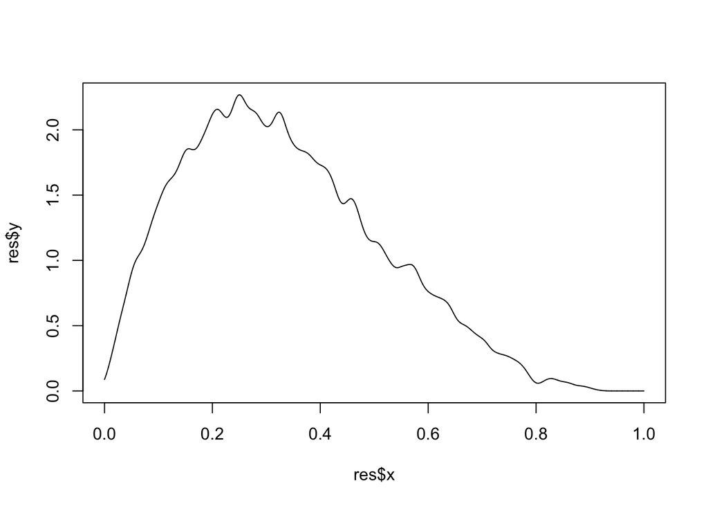

```r
#Choix de h petit h=0.01: estimateur très oscillant

res=bkde(DataReg$X, kernel = "normal",canonical=FALSE, bandwidth=0.01,
         gridsize = length(DataReg$X), c(0,1), truncate = TRUE)
plot(res$x,res$y,type="l")
```

La fonction est très irrégulière et de sous-lissage.

- Cas h un peu plus grand : h = .02

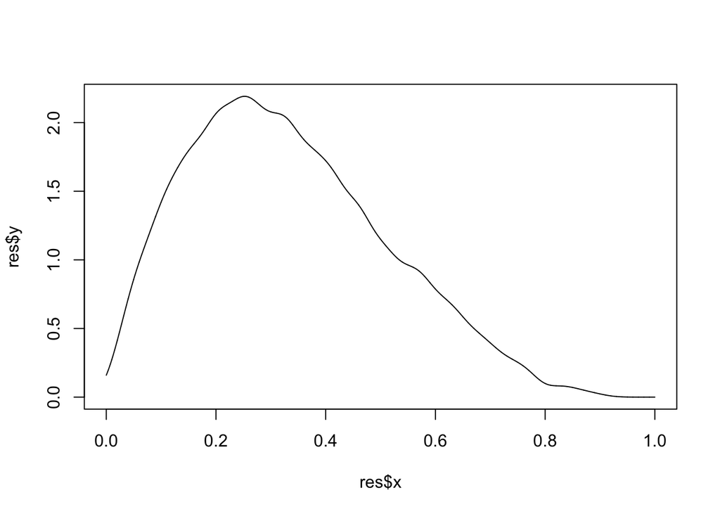

```r
#Choix de h h=0.02

res=bkde(DataReg$X, kernel = "normal",canonical=FALSE, bandwidth=0.02,
         gridsize = length(DataReg$X), c(0,1), truncate = TRUE)
plot(res$x,res$y,type="l")
```

Fonction plus lisse que celle ci-dessus mais toujours irrégulière.

- Cas h proche du h optimal : h = .05

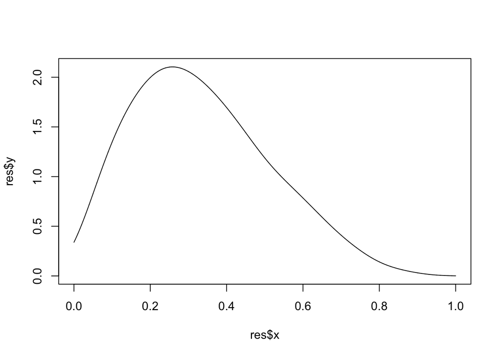

```r
# Choix de h plus grand  h=0.05

res=bkde(DataReg$X, kernel = "normal",canonical=FALSE, bandwidth=0.05,
         gridsize = length(DataReg$X), c(0,1), truncate = TRUE)
plot(res$x,res$y,type="l")
```

- Cas d’un h grand : h = .3

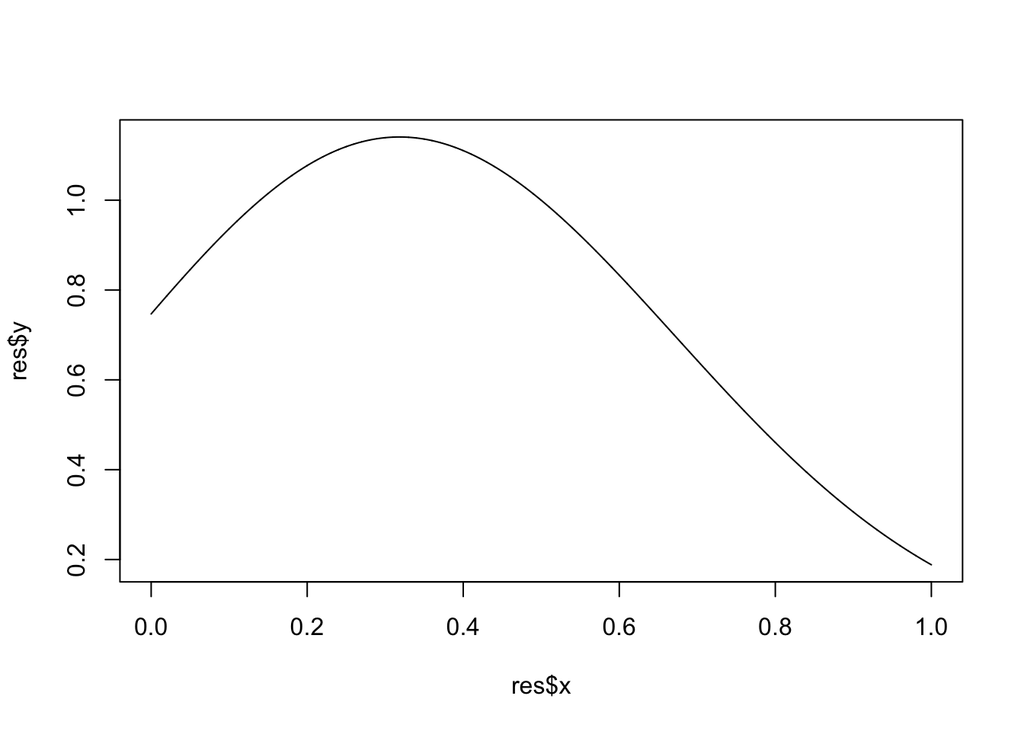

```r
# Choix de h=0.3

res=bkde(DataReg$X, kernel = "normal",canonical=FALSE, bandwidth=0.3,
         gridsize = length(DataReg$X), c(0,1), truncate = TRUE)
plot(res$x,res$y,type="l")
```

Estimateur trop lisse et apparition du problème de sur-lissage.

2. Calcul du h optimal par validation croisée

2.1 Fonction de calcul de la fenêtre de lissage par validation croiée

La fonction J ci-dessous calcul un estimateur de l’erreur quadratique par validation croisée pour chaque valeur de la fenêtre de lissage :

```r
J=function(h){
  fhat=Vectorize(function(x) density(DataReg$X,kernel="epanechnikov",
                                     from=x,to=x,n=1,bw=h)$y)
  fhati=Vectorize(function(i) density(DataReg$X[-i],kernel="epanechnikov",
                                      from=DataReg$X[i],to=DataReg$X[i],n=1,bw=h)$y)
  F=fhati(1:length(DataReg$X))
  #f <- function(x) integrate(function(x) fhat(x)^2,-Inf,Inf)$value-2*mean(F)
  #print(optimise(integrate(function(x) fhat(x)^2,-Inf,Inf)$value-2*mean(F), c(0, 1), tol = 0.001))
  return(integrate(function(x) fhat(x)^2,-Inf,Inf, subdivisions=2000)$value-2*mean(F))
   }
```

2.2 Calcul de la fenêtre de lissage optimale par validation croiée

Le code ci-dessous calcul l’erreur quadratique pour une séquence de valeurs de la fenêtre de lissage. Le h optimal est déduit graphiquement.

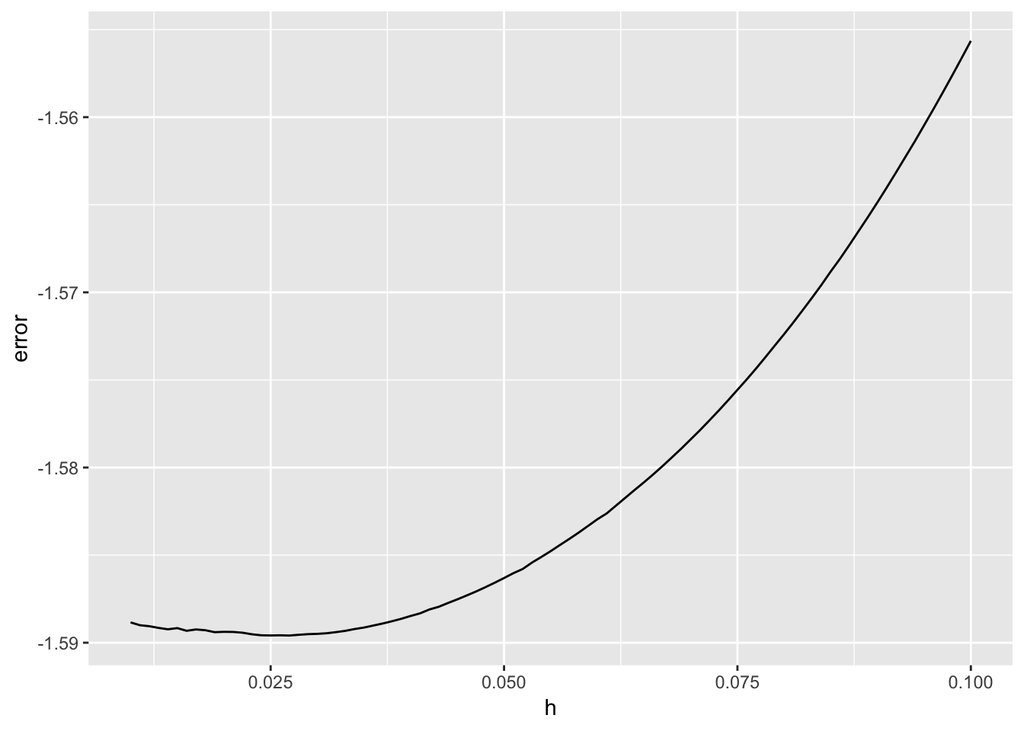

```r
h=seq(0.01,.1,by=.001)
error =Vectorize(J)(h)
df=data.frame(h,error)

qplot(h,error,geom="line",data=df)
```

On peut également utiliser la fonction hcv du package sm pour confirmer cette valeur :

```r
hoptimal <- hcv(DataReg$X, hstart = 0.01, hend = 1)
print(hoptimal)
```

```
## [1] 0.0216403
```

la valeur obtenue est proche de la valeur obtenue précédement.

2.3 Représentation graphique avec le h optimal

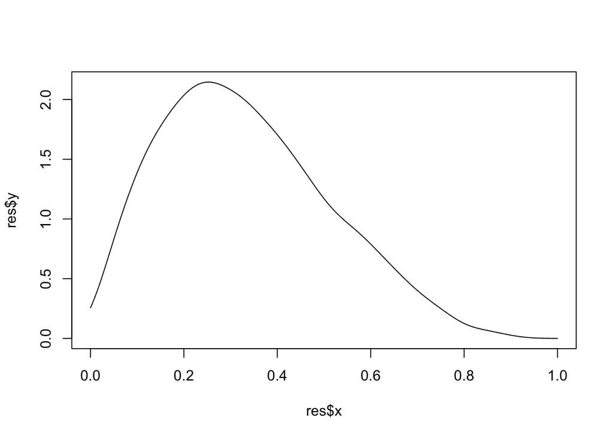

```r
# h optimal : h=0.03

res=bkde(DataReg$X, kernel = "normal",canonical=FALSE, bandwidth=0.035,
         gridsize = length(DataReg$X), c(0,1), truncate = TRUE)
plot(res$x,res$y,type="l")
```

3. Implémenter le QQplot

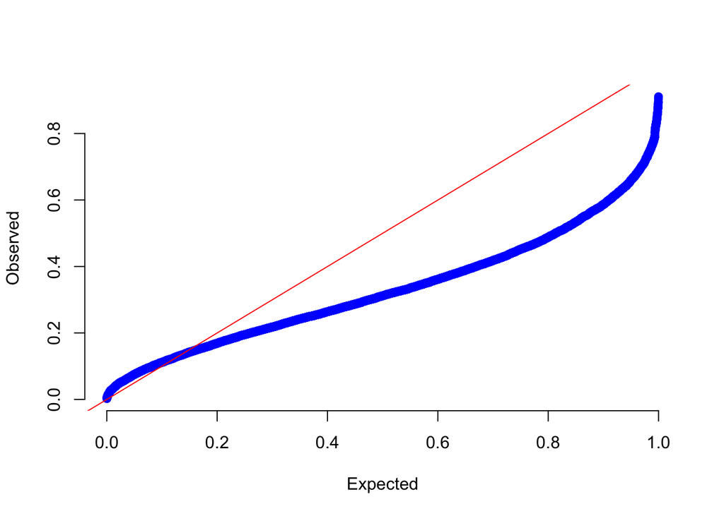

```r
r <- qqunif(DataReg$X,type="unif",logscale=FALSE,base=10,
            col="blue",lcol="red",ci=FALSE,alpha=0.05, pch=21,bg="blue",bty="n")
```

D’après le graphique ci-dessus, la fonction est g est loin d’être uniforme sur l’intervalle {0,1}.

# Reconstruction de r(x)

1. r est-elle linéaire ?

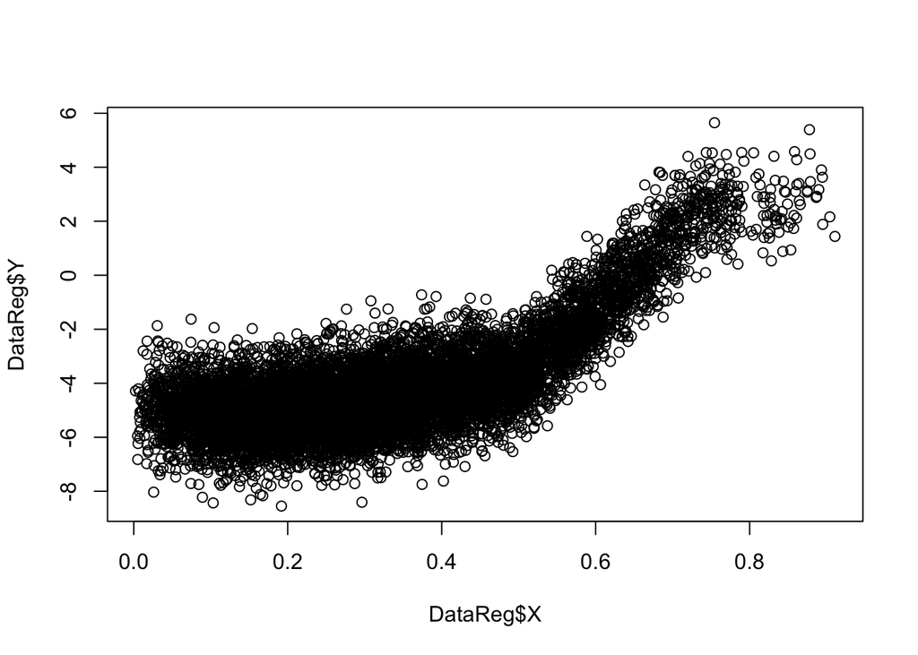

```r
plot(DataReg$X,DataReg$Y)
```

```r
#qqnorm(DataReg$Y)
```

D’après le graphique ci-dessous, on constate que la fonction r n’est pas linéraire sur tout l’intervalle [0,1] mais plutôt linéaire par morceaux sur les deux intervalles [0,0.5] et [0.5,1].

La régression non paramétrique permet entre autres de repérer les différents intervalles (morceaux) sur lesquels la fonction r est linéaire. C’est donc une première étape pour implémenter la régression linéaire.

2. Estimateur non paramétrique de r(x)

2.1 Construction d’un estimateur non paramétrique de r(x) pour différentes valeurs de h

- Cas h petit : h = .01

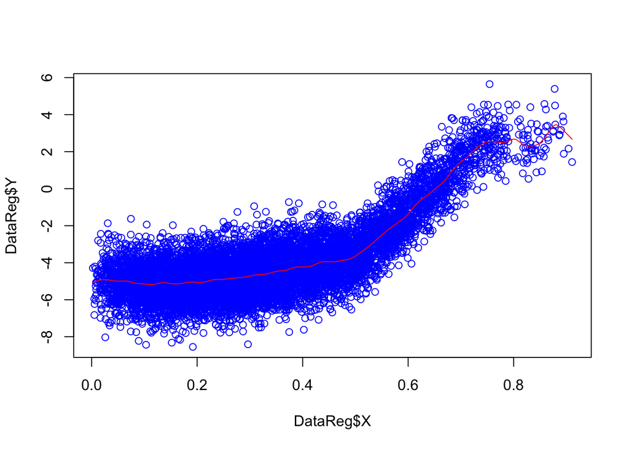

```r
#Choix de h petit
#res <- locpoly(X,Y,drv=0,degree=2,kernel="normal",bandwidth=0.08)


#res=ksmooth(X,Y,kernel="normal",bandwidth=0.01)
res=locpoly(DataReg$X,DataReg$Y,drv=0,degree=0,kernel="normal",bandwidth=0.01)
plot(DataReg$X,DataReg$Y, col = "blue")
lines(res$x,res$y,type="l", col = "red")
```

La fonction est très irrégulière pour h = 0.01

- Cas h un peu plus grand : h = .05

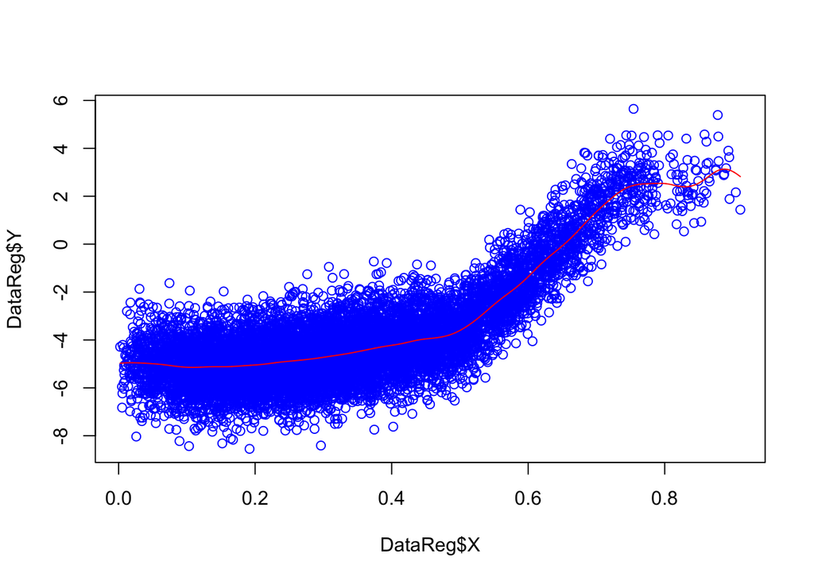

```r
#Choix de h égal à .05 et fonction ksmooth

res=ksmooth(DataReg$X,DataReg$Y,kernel="normal",bandwidth=0.05)
plot(DataReg$X,DataReg$Y, col = "blue")
lines(res$x,res$y,type="l", col = "red")
```

La fonction est toujours osciallante et n’est pas lisse partout.

- Cas h encore plus grand : h = .1

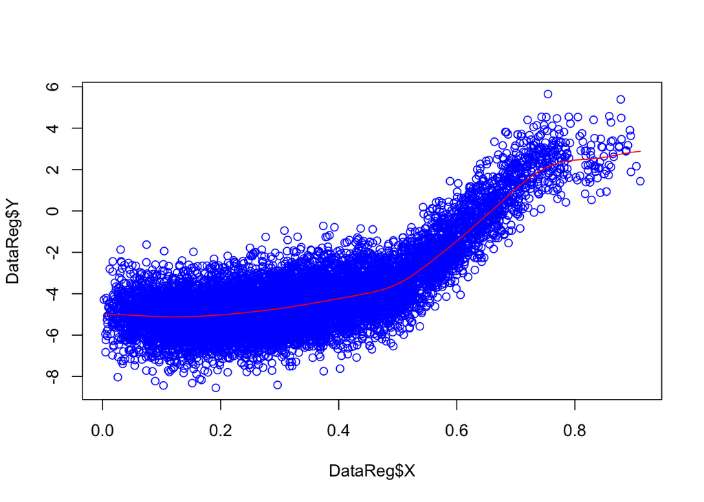

```r
#Choix de h 0.1

res=ksmooth(DataReg$X,DataReg$Y,kernel="normal",bandwidth=0.1)
plot(DataReg$X,DataReg$Y, col = "blue")
lines(res$x,res$y,type="l", col = "red")
```

La fonction est plus lisse que la première mais toujours oscillante.

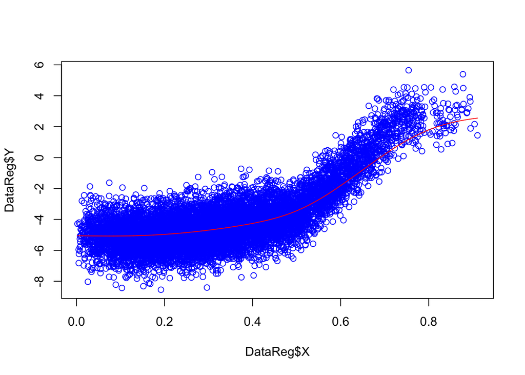

```r
#Choix de h 0.2

res=ksmooth(DataReg$X,DataReg$Y,kernel="normal",bandwidth=0.2)
plot(DataReg$X,DataReg$Y, col = "blue")
lines(res$x,res$y,type="l", col = "red")
```

3. Choix de la fenêtre de lissage

```r
# VALIDATION CROISEE du cours avec la fonction ksmooth pacgkage stat

CVbwt=function(grid,X,Y){
  JJ=function(h){
    fhati=Vectorize(function(i) ksmooth(X[-i],Y[-i],kernel="normal",
                                        bandwidth=h,x.points=X[i])$y)
    Forecast=fhati(1:length(X))
    #return(integrate(function(x) fhat(x)^2,-Inf,Inf)$value-2*mean(FF))
    return(mean((Y-Forecast)**2))
    print(paste0("nombre NaN Forecast : ", length(-which(is.na(Forecast)))))
  }
  vy=Vectorize(JJ)(grid)

  return(vy)

}
```

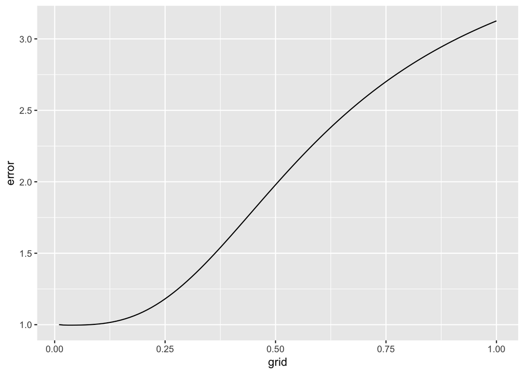

```r
grid=seq(0.01,1 ,by = 0.01)
error <- CVbwt(grid,DataReg$X,DataReg$Y)
df=data.frame(grid,error)

qplot(grid,error,geom="line",data=df)
```

Le h oprimal par validation croisé est égal à :

```r
h_dpill=dpill(DataReg$X,DataReg$Y)
print(h_dpill)
```

```
## [1] 0.01800528
```

Le h optimal par cette fonction est de 0.018.

3. Choix du h local ou glabal

Calcul du h local

```r
# Calcul des h locaux avec la fonction dpill dépendant "localement" des valeurs de X

h_CVloc=function(X,Y,N_block){
  #N_block multiple de n
  n=length(X)
  h_loc=rep(-1,N_block)
  if((n/N_block)%%1!=0){ print("error n should be a multiple of N_block")}
  X_sort=sort(X)
  Y_sort=Y[order(X)]
  for(i in 1:N_block){
    h_loc[i]=dpill(X[((i-1)*(n/N_block)+1):(i*(n/N_block))],
                   Y[((i-1)*(n/N_block)+1):(i*(n/N_block))])
  }
  h_locG=rep(h_loc,each=400/N_block)
  return(list("h_loc"=h_loc,"h_locG"=h_locG))
}
```

Calcul du h global – Par validation croisée

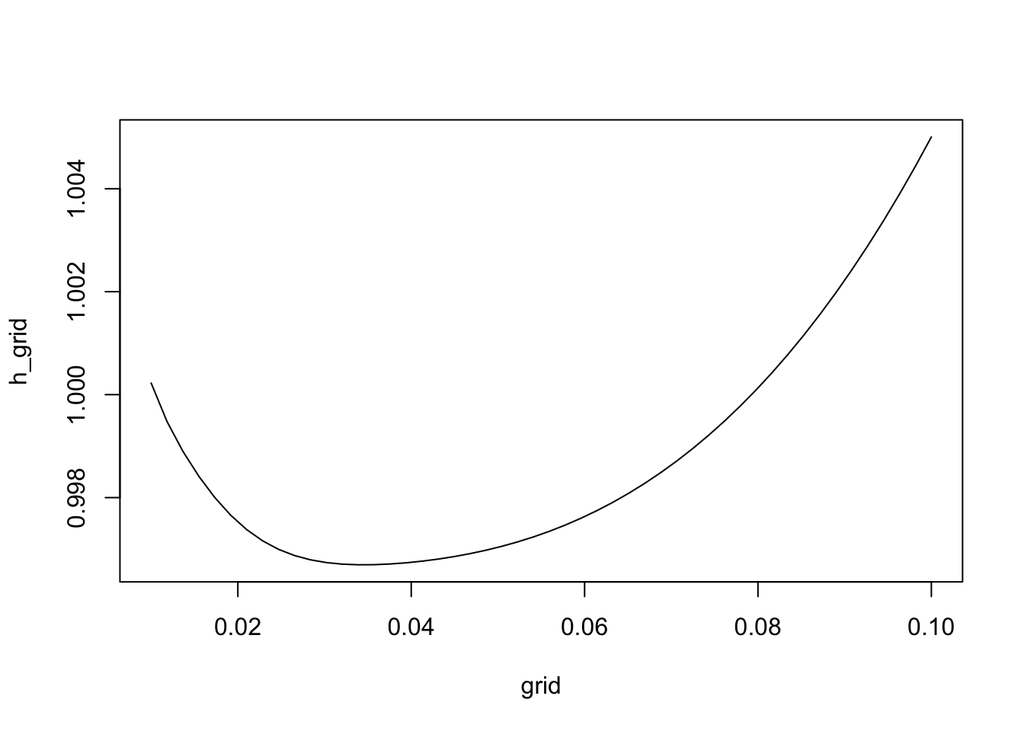

```r
# Calcul du h global par Validation croisée
grid=seq(0.01,0.1,length=50)
h_grid=CVbwt(grid,DataReg$X,DataReg$Y)
plot(grid,h_grid,type="l")
```

Le h optimal global par validation croisée est de 0.035

– par fonction dpill

```r
# Calcul du h global
hglobal=dpill(DataReg$X,DataReg$Y)
#hglobal <- 0.01800528
print(hglobal)
```

```
## [1] 0.01800528
```

Le h optimal global par dpill est de 0.018

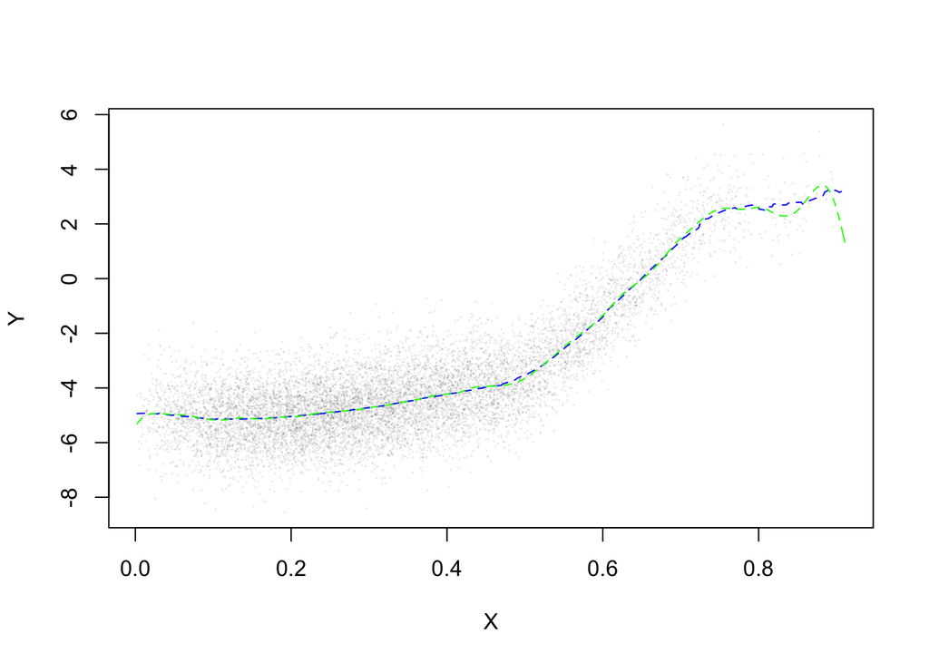

```r
# Test: choix de $h$ local
h_CVopt=h_CVloc(DataReg$X,DataReg$Y,100)

if(length(which(is.na(h_CVopt$h_locG)))==0){h=h_CVopt$h_locG}else{h=h_CVopt$h_locG[-which(is.na(h_CVopt$h_locG))]}
#h
#print(h)

#plot(h)
#lines(hglobal,type="l",col="red")
Y_CVopt=locpoly(DataReg$X,DataReg$Y,drv=0,degree=2,kernel="normal",gridsize=length(h),bandwidth=h)
Y_CVglobal=locpoly(DataReg$X,DataReg$Y,drv=0,degree=2,kernel="normal",bandwidth=hglobal)
plot(DataReg$X,DataReg$Y,pch=20,cex=0.01,xlab="X",ylab="Y")
#lines(Y_CVopt$x,col="red")
lines(Y_CVopt,lty="dashed",col="blue")
lines(Y_CVglobal,lty="dashed",col="green")
```

On constate que le h global est sensible aux extrémités des intervalles. Ce n’est pas le cas pour le h local.

3. Etude de la loi des ei

3.1 Implémnter Un et Vn

- Calcul Un

```r
Yi1 <- DataReg$Y[c(2:length(DataReg$Y))]
Yi <- DataReg$Y[c(1:length(DataReg$Y) - 1)]

Un <- max(cumsum((Yi1 - Yi)^2) /(2 * (length(DataReg$Y) - 1)))
print(Un)
```

```
## [1] 3.913353
```

la valeur de Un est égale 3.913353

- Calcul Vn

```r
tilde_Yi <- DataReg$Y[order(DataReg$X)]
tilde_Yi1 <- tilde_Yi[c(2:length(tilde_Yi))]


tilde_Yi <- tilde_Yi[c(1:length(tilde_Yi) - 1)]

Vn <- max(cumsum((tilde_Yi1 - tilde_Yi)^2) /(2 * (length(DataReg$Y) - 1)))
print(Vn)
```

```
## [1] 1.005674
```

la valeur de Vn est égale 1.005674

3.2 Justifier ce qu’estiment ces deux quantités Un et Vn – Estimateur Un

Un correspond à la variance de Y. en effet (Yi1 - Yi)^2 = (Yi1 + E(y) -E(y) - Yi)^2 = (Yi1 - E(y))^2 + (Yi - E(y))^2 - (2 * Yi1 - E(y) * (Yi - E(y)))

Ainsi, si on applique la somme et on divise sur 2*(n-1), le denrier terme s’annule et les deux premiers termes correspondent à la variance de Y.

Ainsi Un = Var(Y)

– Estimateur Vn Vn correspond à un estimateur de la variance de erreurs e. En effet Yi = r(xi) + ei Ainsi, vu que les Xi sont ordonnés : r(xi1) = r(xi) (à peu prés, les points sont proches) tilde_Yi1 − tilde_Yi = r(xi1)+ei1 − r(xi) - ei = ei1 −ei

E(tilde_Yi1 − tilde_Yi)^2 = E(ei1^2) + E(ei^2) − 2E(ei1)E(ei) = E(ei1^2) + E(ei^2) = 2sigma^2 On a E(tilde_sigma^2) = sigma^2 Ainsi Vn correspond à un estimateur de la variance de erreurs e